# Chapter 6 Lab 1

## 6.5.1 - Best Subset Selection

Predict `Salary` on the basis of various statistics with performance.

`is.na()` can be used to identify missing obs.

```r
library(ISLR)

attach(Hitters)

names(Hitters)
```

```
 [1] "AtBat"     "Hits"      "HmRun"     "Runs"      "RBI"       "Walks"     "Years"     "CAtBat"
 [9] "CHits"     "CHmRun"    "CRuns"     "CRBI"      "CWalks"    "League"    "Division"  "PutOuts"
[17] "Assists"   "Errors"    "Salary"    "NewLeague"
```

```r
dim(Hitters)
```

```
[1] 322  20
```

```r
sum(is.na(Hitters$Salary))
```

```
[1] 59
```

`na.omit` can be used to remove all rows with missing values in *any* variable.

```r
Hitters = na.omit(Hitters)

dim(Hitters)
```

```
[1] 263  20
```

```r
sum(is.na(Hitters))
```

```
[1] 0
```

`regsubsets()`, part of the `leaps` library performs best subset selection by identifying the best model that contains a given number of predictors, where `best` is quantified using RSS.

```r
library(leaps)

regfit.full = regsubsets(Salary ~ .,
                         Hitters,
                         nvmax = 19) # Otherwise, default is 8

reg.summary = summary(regfit.full)

reg.summary
```

```
Subset selection object
Call: regsubsets.formula(Salary ~ ., Hitters, nvmax = 19)
19 Variables  (and intercept)
           Forced in Forced out
AtBat          FALSE      FALSE
Hits           FALSE      FALSE
HmRun          FALSE      FALSE
Runs           FALSE      FALSE
RBI            FALSE      FALSE
Walks          FALSE      FALSE
Years          FALSE      FALSE
CAtBat         FALSE      FALSE
CHits          FALSE      FALSE
CHmRun         FALSE      FALSE
CRuns          FALSE      FALSE
CRBI           FALSE      FALSE
CWalks         FALSE      FALSE
LeagueN        FALSE      FALSE
DivisionW      FALSE      FALSE
PutOuts        FALSE      FALSE
Assists        FALSE      FALSE
Errors         FALSE      FALSE
NewLeagueN     FALSE      FALSE
1 subsets of each size up to 19
Selection Algorithm: exhaustive
          AtBat Hits HmRun Runs RBI Walks Years CAtBat CHits CHmRun CRuns CRBI CWalks LeagueN DivisionW
1  ( 1 )  " "   " "  " "   " "  " " " "   " "   " "    " "   " "    " "   "*"  " "    " "     " "
2  ( 1 )  " "   "*"  " "   " "  " " " "   " "   " "    " "   " "    " "   "*"  " "    " "     " "
3  ( 1 )  " "   "*"  " "   " "  " " " "   " "   " "    " "   " "    " "   "*"  " "    " "     " "
4  ( 1 )  " "   "*"  " "   " "  " " " "   " "   " "    " "   " "    " "   "*"  " "    " "     "*"
5  ( 1 )  "*"   "*"  " "   " "  " " " "   " "   " "    " "   " "    " "   "*"  " "    " "     "*"
6  ( 1 )  "*"   "*"  " "   " "  " " "*"   " "   " "    " "   " "    " "   "*"  " "    " "     "*"
7  ( 1 )  " "   "*"  " "   " "  " " "*"   " "   "*"    "*"   "*"    " "   " "  " "    " "     "*"
8  ( 1 )  "*"   "*"  " "   " "  " " "*"   " "   " "    " "   "*"    "*"   " "  "*"    " "     "*"
9  ( 1 )  "*"   "*"  " "   " "  " " "*"   " "   "*"    " "   " "    "*"   "*"  "*"    " "     "*"
10  ( 1 ) "*"   "*"  " "   " "  " " "*"   " "   "*"    " "   " "    "*"   "*"  "*"    " "     "*"
11  ( 1 ) "*"   "*"  " "   " "  " " "*"   " "   "*"    " "   " "    "*"   "*"  "*"    "*"     "*"
12  ( 1 ) "*"   "*"  " "   "*"  " " "*"   " "   "*"    " "   " "    "*"   "*"  "*"    "*"     "*"
13  ( 1 ) "*"   "*"  " "   "*"  " " "*"   " "   "*"    " "   " "    "*"   "*"  "*"    "*"     "*"
14  ( 1 ) "*"   "*"  "*"   "*"  " " "*"   " "   "*"    " "   " "    "*"   "*"  "*"    "*"     "*"
```

[output cut: 10 more lines]

```
5  ( 1 )  "*"     " "     " "    " "
6  ( 1 )  "*"     " "     " "    " "
7  ( 1 )  "*"     " "     " "    " "
8  ( 1 )  "*"     " "     " "    " "
9  ( 1 )  "*"     " "     " "    " "
10  ( 1 ) "*"     "*"     " "    " "
11  ( 1 ) "*"     "*"     " "    " "
12  ( 1 ) "*"     "*"     " "    " "
13  ( 1 ) "*"     "*"     "*"    " "
14  ( 1 ) "*"     "*"     "*"    " "
15  ( 1 ) "*"     "*"     "*"    " "
16  ( 1 ) "*"     "*"     "*"    " "
17  ( 1 ) "*"     "*"     "*"    "*"
18  ( 1 ) "*"     "*"     "*"    "*"
19  ( 1 ) "*"     "*"     "*"    "*"
```

`*` means to be included in the corresponding model (e.g. best two-variable model contains `Hits` and `CRBI`).

`summary()` also returns other statistics.

```r
names(reg.summary)
```

```
[1] "which"  "rsq"    "rss"    "adjr2"  "cp"     "bic"    "outmat" "obj"
```

$R^2$ increases from 32% (one-variable) to 55% (nineteen-variable).

```r
reg.summary$rsq
```

```
 [1] 0.3214501 0.4252237 0.4514294 0.4754067 0.4908036 0.5087146 0.5141227 0.5285569 0.5346124 0.5404950
[11] 0.5426153 0.5436302 0.5444570 0.5452164 0.5454692 0.5457656 0.5459518 0.5460945 0.5461159
```

$AdjR^2$ also increased.

```r
reg.summary$adjr2
```

```
 [1] 0.3188503 0.4208024 0.4450753 0.4672734 0.4808971 0.4972001 0.5007849 0.5137083 0.5180572 0.5222606
[11] 0.5225706 0.5217245 0.5206736 0.5195431 0.5178661 0.5162219 0.5144464 0.5126097 0.5106270
```

Plot the statistics.

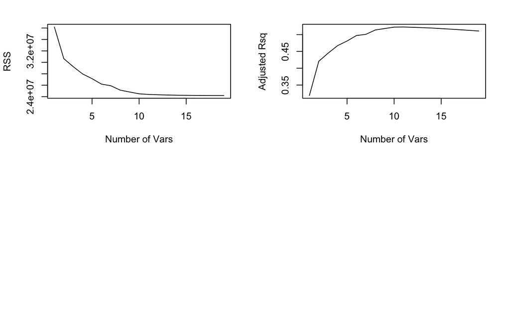

```r
par(mfrow=c(2,2))

plot(reg.summary$rss,
     xlab = "Number of Vars",
     ylab = "RSS",
     type = "l") # type = "l" is used to connect plotted points with lines

plot(reg.summary$adjr2,
     xlab = "Number of Vars",
     ylab = "Adjusted Rsq",
     type = "l") # type = "l" is used to connect plotted points with lines
```

`which.max()` can be used to identify the location of the max point of a vector.

```r
which.max(reg.summary$adjr2)
```

```
[1] 11
```

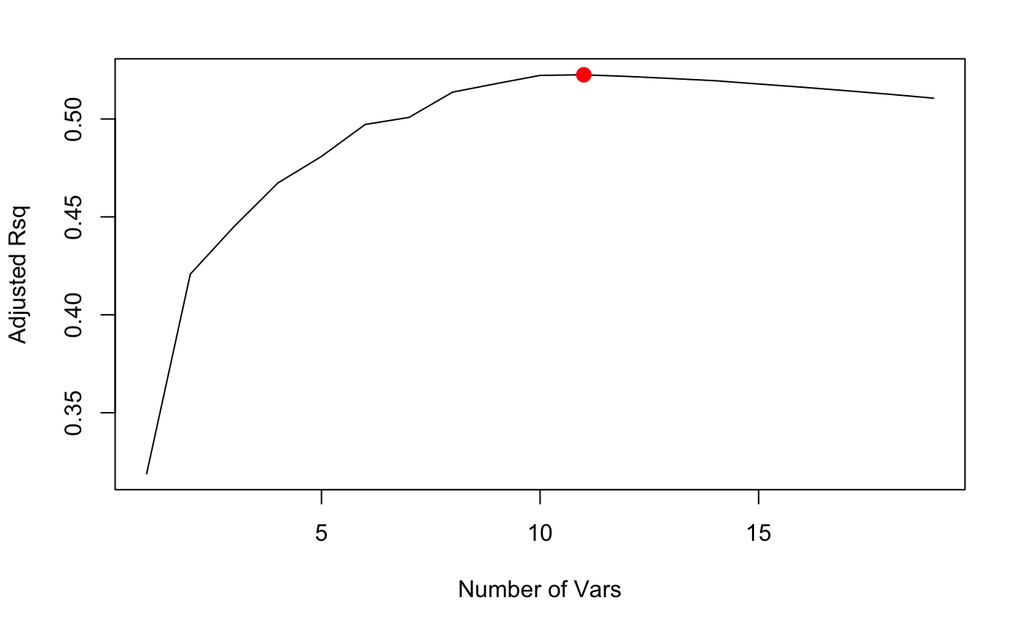

```r
plot(reg.summary$adjr2,
     xlab = "Number of Vars",
     ylab = "Adjusted Rsq",
     type = "l")

points(11,
       reg.summary$adjr2[11],
       col = "red",
       cex = 2,
       pch = 20)
```

Now plot $C_p$.

```r
plot(reg.summary$cp,
     xlab = "Number of Vars",
     ylab = "Cp",
     type = "l")

which.min(reg.summary$cp)
```

```
[1] 10
```

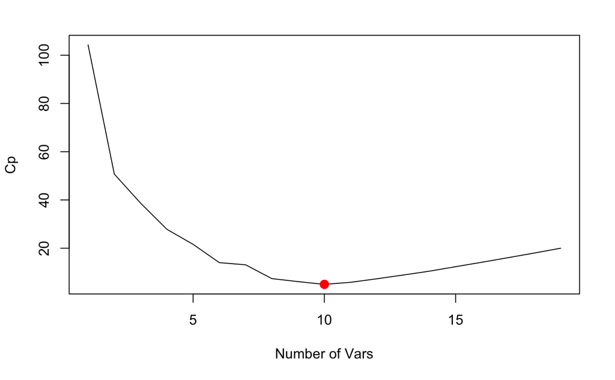

```r
points(10,
       reg.summary$cp[10],
       col = "red",
       cex = 2,
       pch = 20)
```

Now plot $BIC$.

```r
plot(reg.summary$bic,
     xlab = "Number of Vars",
     ylab = "BIC",
     type = "l")

which.min(reg.summary$bic)
```

```
[1] 6
```

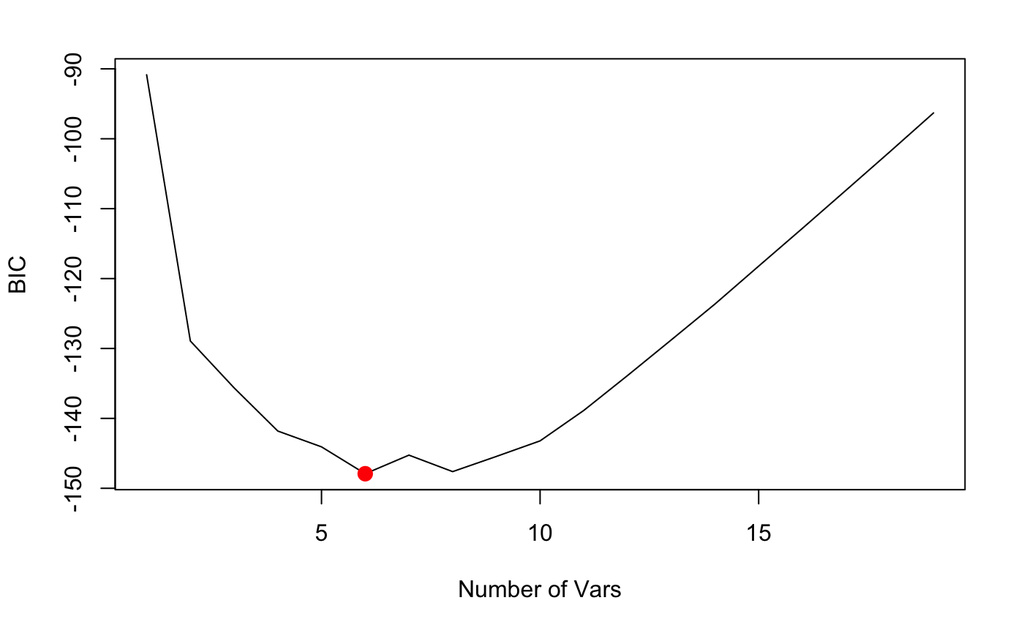

```r
points(6,
       reg.summary$bic[6],
       col = "red",
       cex = 2,
       pch = 20)
```

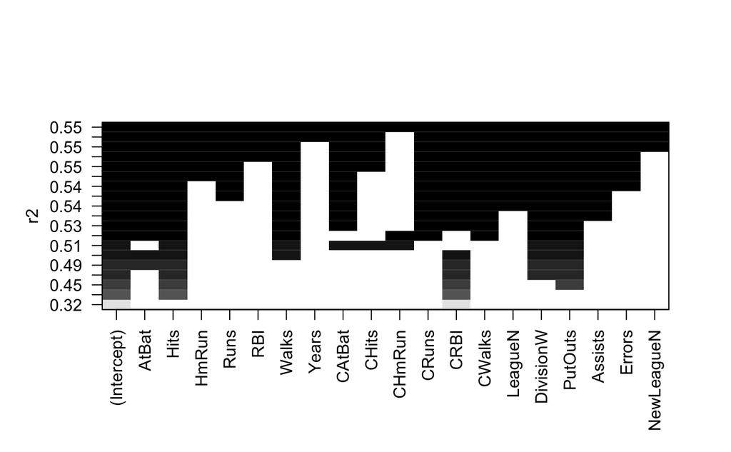

```r
plot(regfit.full, scale="r2")
```

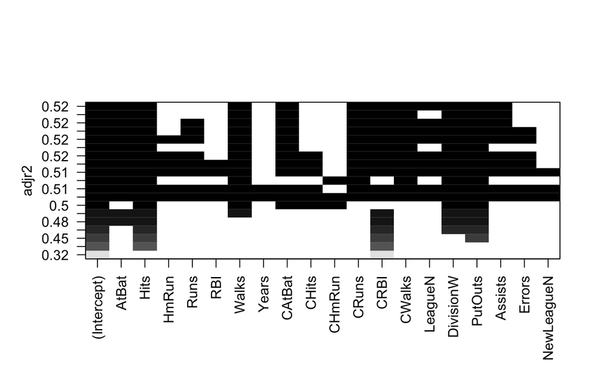

```r
plot(regfit.full, scale="adjr2")
```

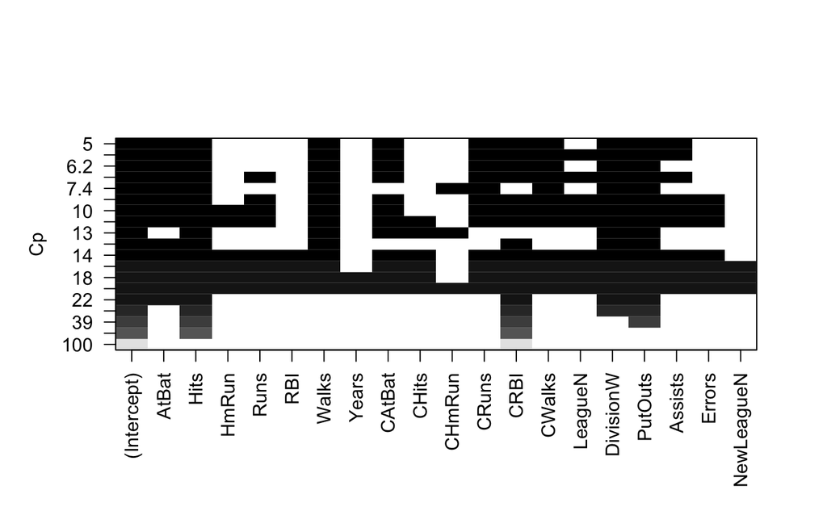

```r
plot(regfit.full, scale="Cp")
```

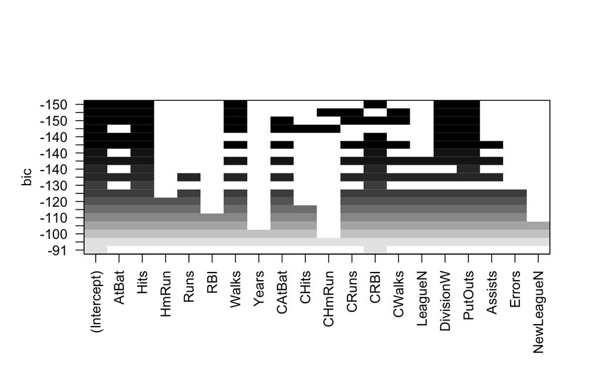

```r
plot(regfit.full, scale="bic")
```

Top row of each plot contains a black square for each variable selected according to the optimal model associated with that statistics.

```r
coef(regfit.full, 6)
```

```
 (Intercept)        AtBat         Hits        Walks         CRBI    DivisionW      PutOuts
  91.5117981   -1.8685892    7.6043976    3.6976468    0.6430169 -122.9515338    0.2643076
```

## 6.5.2 - Forward and Backward Stepwise Selection

```r
regfit.fwd = regsubsets(Salary ~ .,
                        Hitters,
                        nvmax = 19,
                        method = "forward")

summary(regfit.fwd)
```

```
Subset selection object
Call: regsubsets.formula(Salary ~ ., Hitters, nvmax = 19, method = "forward")
19 Variables  (and intercept)
           Forced in Forced out
AtBat          FALSE      FALSE
Hits           FALSE      FALSE
HmRun          FALSE      FALSE
Runs           FALSE      FALSE
RBI            FALSE      FALSE
Walks          FALSE      FALSE
Years          FALSE      FALSE
CAtBat         FALSE      FALSE
CHits          FALSE      FALSE
CHmRun         FALSE      FALSE
CRuns          FALSE      FALSE
CRBI           FALSE      FALSE
CWalks         FALSE      FALSE
LeagueN        FALSE      FALSE
DivisionW      FALSE      FALSE
PutOuts        FALSE      FALSE
Assists        FALSE      FALSE
Errors         FALSE      FALSE
NewLeagueN     FALSE      FALSE
1 subsets of each size up to 19
Selection Algorithm: forward
          AtBat Hits HmRun Runs RBI Walks Years CAtBat CHits CHmRun CRuns CRBI CWalks LeagueN DivisionW
1  ( 1 )  " "   " "  " "   " "  " " " "   " "   " "    " "   " "    " "   "*"  " "    " "     " "
2  ( 1 )  " "   "*"  " "   " "  " " " "   " "   " "    " "   " "    " "   "*"  " "    " "     " "
3  ( 1 )  " "   "*"  " "   " "  " " " "   " "   " "    " "   " "    " "   "*"  " "    " "     " "
4  ( 1 )  " "   "*"  " "   " "  " " " "   " "   " "    " "   " "    " "   "*"  " "    " "     "*"
5  ( 1 )  "*"   "*"  " "   " "  " " " "   " "   " "    " "   " "    " "   "*"  " "    " "     "*"
6  ( 1 )  "*"   "*"  " "   " "  " " "*"   " "   " "    " "   " "    " "   "*"  " "    " "     "*"
7  ( 1 )  "*"   "*"  " "   " "  " " "*"   " "   " "    " "   " "    " "   "*"  "*"    " "     "*"
8  ( 1 )  "*"   "*"  " "   " "  " " "*"   " "   " "    " "   " "    "*"   "*"  "*"    " "     "*"
9  ( 1 )  "*"   "*"  " "   " "  " " "*"   " "   "*"    " "   " "    "*"   "*"  "*"    " "     "*"
10  ( 1 ) "*"   "*"  " "   " "  " " "*"   " "   "*"    " "   " "    "*"   "*"  "*"    " "     "*"
11  ( 1 ) "*"   "*"  " "   " "  " " "*"   " "   "*"    " "   " "    "*"   "*"  "*"    "*"     "*"
12  ( 1 ) "*"   "*"  " "   "*"  " " "*"   " "   "*"    " "   " "    "*"   "*"  "*"    "*"     "*"
13  ( 1 ) "*"   "*"  " "   "*"  " " "*"   " "   "*"    " "   " "    "*"   "*"  "*"    "*"     "*"
14  ( 1 ) "*"   "*"  "*"   "*"  " " "*"   " "   "*"    " "   " "    "*"   "*"  "*"    "*"     "*"
```

[output cut: 10 more lines]

```
5  ( 1 )  "*"     " "     " "    " "
6  ( 1 )  "*"     " "     " "    " "
7  ( 1 )  "*"     " "     " "    " "
8  ( 1 )  "*"     " "     " "    " "
9  ( 1 )  "*"     " "     " "    " "
10  ( 1 ) "*"     "*"     " "    " "
11  ( 1 ) "*"     "*"     " "    " "
12  ( 1 ) "*"     "*"     " "    " "
13  ( 1 ) "*"     "*"     "*"    " "
14  ( 1 ) "*"     "*"     "*"    " "
15  ( 1 ) "*"     "*"     "*"    " "
16  ( 1 ) "*"     "*"     "*"    " "
17  ( 1 ) "*"     "*"     "*"    "*"
18  ( 1 ) "*"     "*"     "*"    "*"
19  ( 1 ) "*"     "*"     "*"    "*"
```

```r
regfit.bwd = regsubsets(Salary ~ .,
                        Hitters,
                        nvmax = 19,
                        method = "backward")

summary(regfit.bwd)
```

```
Subset selection object
Call: regsubsets.formula(Salary ~ ., Hitters, nvmax = 19, method = "backward")
19 Variables  (and intercept)
           Forced in Forced out
AtBat          FALSE      FALSE
Hits           FALSE      FALSE
HmRun          FALSE      FALSE
Runs           FALSE      FALSE
RBI            FALSE      FALSE
Walks          FALSE      FALSE
Years          FALSE      FALSE
CAtBat         FALSE      FALSE
CHits          FALSE      FALSE
CHmRun         FALSE      FALSE
CRuns          FALSE      FALSE
CRBI           FALSE      FALSE
CWalks         FALSE      FALSE
LeagueN        FALSE      FALSE
DivisionW      FALSE      FALSE
PutOuts        FALSE      FALSE
Assists        FALSE      FALSE
Errors         FALSE      FALSE
NewLeagueN     FALSE      FALSE
1 subsets of each size up to 19
Selection Algorithm: backward
          AtBat Hits HmRun Runs RBI Walks Years CAtBat CHits CHmRun CRuns CRBI CWalks LeagueN DivisionW
1  ( 1 )  " "   " "  " "   " "  " " " "   " "   " "    " "   " "    "*"   " "  " "    " "     " "
2  ( 1 )  " "   "*"  " "   " "  " " " "   " "   " "    " "   " "    "*"   " "  " "    " "     " "
3  ( 1 )  " "   "*"  " "   " "  " " " "   " "   " "    " "   " "    "*"   " "  " "    " "     " "
4  ( 1 )  "*"   "*"  " "   " "  " " " "   " "   " "    " "   " "    "*"   " "  " "    " "     " "
5  ( 1 )  "*"   "*"  " "   " "  " " "*"   " "   " "    " "   " "    "*"   " "  " "    " "     " "
6  ( 1 )  "*"   "*"  " "   " "  " " "*"   " "   " "    " "   " "    "*"   " "  " "    " "     "*"
7  ( 1 )  "*"   "*"  " "   " "  " " "*"   " "   " "    " "   " "    "*"   " "  "*"    " "     "*"
8  ( 1 )  "*"   "*"  " "   " "  " " "*"   " "   " "    " "   " "    "*"   "*"  "*"    " "     "*"
9  ( 1 )  "*"   "*"  " "   " "  " " "*"   " "   "*"    " "   " "    "*"   "*"  "*"    " "     "*"
10  ( 1 ) "*"   "*"  " "   " "  " " "*"   " "   "*"    " "   " "    "*"   "*"  "*"    " "     "*"
11  ( 1 ) "*"   "*"  " "   " "  " " "*"   " "   "*"    " "   " "    "*"   "*"  "*"    "*"     "*"
12  ( 1 ) "*"   "*"  " "   "*"  " " "*"   " "   "*"    " "   " "    "*"   "*"  "*"    "*"     "*"
13  ( 1 ) "*"   "*"  " "   "*"  " " "*"   " "   "*"    " "   " "    "*"   "*"  "*"    "*"     "*"
14  ( 1 ) "*"   "*"  "*"   "*"  " " "*"   " "   "*"    " "   " "    "*"   "*"  "*"    "*"     "*"
```

[output cut: 10 more lines]

```
5  ( 1 )  "*"     " "     " "    " "
6  ( 1 )  "*"     " "     " "    " "
7  ( 1 )  "*"     " "     " "    " "
8  ( 1 )  "*"     " "     " "    " "
9  ( 1 )  "*"     " "     " "    " "
10  ( 1 ) "*"     "*"     " "    " "
11  ( 1 ) "*"     "*"     " "    " "
12  ( 1 ) "*"     "*"     " "    " "
13  ( 1 ) "*"     "*"     "*"    " "
14  ( 1 ) "*"     "*"     "*"    " "
15  ( 1 ) "*"     "*"     "*"    " "
16  ( 1 ) "*"     "*"     "*"    " "
17  ( 1 ) "*"     "*"     "*"    "*"
18  ( 1 ) "*"     "*"     "*"    "*"
19  ( 1 ) "*"     "*"     "*"    "*"
```

## 6.5.3 - Choosing Among Models Using the Validation Set Approach and Cross-Validation

First, split into training set and test set.

```r
set.seed(647)

train = sample(c(TRUE, FALSE),
               nrow(Hitters),
               rep = TRUE)

test = (!train)

length(train)
```

```
[1] 263
```

```r
test[1:10]
```

```
 [1] FALSE  TRUE FALSE  TRUE  TRUE FALSE  TRUE FALSE  TRUE FALSE
```

Apply `regsubsets()` to the training set to perform best subset selection.

```r
regfit.best = regsubsets(Salary ~ .,
                         Hitters[train,],
                         nvmax = 19)

summary(regfit.best)
```

```
Subset selection object
Call: regsubsets.formula(Salary ~ ., Hitters[train, ], nvmax = 19)
19 Variables  (and intercept)
           Forced in Forced out
AtBat          FALSE      FALSE
Hits           FALSE      FALSE
HmRun          FALSE      FALSE
Runs           FALSE      FALSE
RBI            FALSE      FALSE
Walks          FALSE      FALSE
Years          FALSE      FALSE
CAtBat         FALSE      FALSE
CHits          FALSE      FALSE
CHmRun         FALSE      FALSE
CRuns          FALSE      FALSE
CRBI           FALSE      FALSE
CWalks         FALSE      FALSE
LeagueN        FALSE      FALSE
DivisionW      FALSE      FALSE
PutOuts        FALSE      FALSE
Assists        FALSE      FALSE
Errors         FALSE      FALSE
NewLeagueN     FALSE      FALSE
1 subsets of each size up to 19
Selection Algorithm: exhaustive
          AtBat Hits HmRun Runs RBI Walks Years CAtBat CHits CHmRun CRuns CRBI CWalks LeagueN DivisionW
1  ( 1 )  " "   " "  " "   " "  " " " "   " "   " "    " "   " "    "*"   " "  " "    " "     " "
2  ( 1 )  " "   "*"  " "   " "  " " " "   " "   " "    " "   " "    "*"   " "  " "    " "     " "
3  ( 1 )  " "   "*"  " "   " "  " " " "   " "   " "    " "   " "    " "   "*"  " "    " "     "*"
4  ( 1 )  "*"   "*"  " "   " "  " " " "   " "   " "    " "   " "    " "   "*"  " "    " "     "*"
5  ( 1 )  "*"   "*"  " "   " "  " " " "   " "   " "    " "   " "    "*"   " "  " "    " "     "*"
6  ( 1 )  "*"   "*"  " "   " "  " " "*"   " "   " "    " "   " "    " "   "*"  " "    " "     "*"
7  ( 1 )  "*"   "*"  " "   " "  " " " "   " "   "*"    " "   " "    "*"   "*"  " "    " "     "*"
8  ( 1 )  "*"   "*"  " "   " "  " " " "   " "   "*"    " "   " "    "*"   "*"  " "    " "     "*"
9  ( 1 )  "*"   "*"  " "   " "  " " "*"   " "   "*"    "*"   "*"    " "   " "  " "    " "     "*"
10  ( 1 ) "*"   "*"  " "   " "  " " "*"   " "   "*"    "*"   "*"    " "   " "  " "    " "     "*"
11  ( 1 ) "*"   "*"  " "   " "  " " "*"   " "   "*"    " "   " "    "*"   "*"  "*"    "*"     "*"
12  ( 1 ) "*"   "*"  " "   " "  " " "*"   " "   "*"    " "   " "    "*"   "*"  "*"    "*"     "*"
13  ( 1 ) "*"   "*"  " "   " "  " " "*"   " "   "*"    "*"   " "    "*"   "*"  "*"    "*"     "*"
14  ( 1 ) "*"   "*"  "*"   " "  " " "*"   " "   "*"    "*"   " "    "*"   "*"  "*"    "*"     "*"
```

[output cut: 10 more lines]

```
5  ( 1 )  "*"     " "     " "    " "
6  ( 1 )  "*"     " "     " "    " "
7  ( 1 )  "*"     " "     " "    " "
8  ( 1 )  "*"     "*"     " "    " "
9  ( 1 )  "*"     "*"     " "    " "
10  ( 1 ) "*"     "*"     "*"    " "
11  ( 1 ) "*"     "*"     " "    " "
12  ( 1 ) "*"     "*"     "*"    " "
13  ( 1 ) "*"     "*"     "*"    " "
14  ( 1 ) "*"     "*"     "*"    " "
15  ( 1 ) "*"     "*"     "*"    " "
16  ( 1 ) "*"     "*"     "*"    " "
17  ( 1 ) "*"     "*"     "*"    " "
18  ( 1 ) "*"     "*"     "*"    " "
19  ( 1 ) "*"     "*"     "*"    "*"
```

Now computer the validation set error for the best model, of each model size.

```r
test.mat = model.matrix(Salary ~ .,
                        Hitters[test,]) # Build an "X" matrix from data

dim(test.mat)
```

```
[1] 129  20
```

Run a for loop for each size *i* to extract the coefficients from regfit.best for the best model of size *i*.

```r
val.errors = rep(NA, 19)

for (i in 1:19) {
  coefi = coef(regfit.best, id = i) # Get the coefficients of the best model
  pred = test.mat[, names(coefi)]%*%coefi # Multiple the coefficients with the columns and add together to form prediction
  val.errors[i] = mean((Hitters$Salary[test] - pred) ^ 2)

  if (i == 5) {
    print(coefi)
    print(pred)
    print(val.errors[i])
  }
}
```

```
 (Intercept)        AtBat         Hits        CRuns    DivisionW      PutOuts
 135.3328969   -2.5059697   11.4372693    0.5340807 -180.2252172    0.3464415
                         [,1]
-Alvin Davis        666.09577
-Andres Galarraga   630.48031
-Alfredo Griffin    764.73111
-Argenis Salazar    107.06609
-Andre Thornton     601.38708
-Bill Almon         364.49507
-Buddy Biancalana    75.14010
-Bruce Bochy        108.60673
-Barry Bonds        288.05361
-Bob Brenly         407.71743
-Brett Butler       915.02284
-Bob Dernier        390.64686
-Brook Jacoby       750.53959
-Bob Kearney        216.76920
-BillyJo Robidoux   274.30196
-Chris Brown        507.98517
-Carmen Castillo    356.11450
-Chili Davis        599.77710
-Curt Ford          260.08336
-Chet Lemon         789.02509
-Carmelo Martinez   143.79661
-Craig Reynolds     318.00797
-Cory Snyder        486.56523
-Curt Wilkerson     109.44445
-Daryl Boston       145.69668
-Darnell Coles      543.75815
-Doug DeCinces      591.82546
-Darrell Evans     1167.62264
-Dan Gladden        367.90302
-Don Mattingly     1824.30557
-Dwayne Murphy      482.65124
-Dave Parker        967.53148
-Dan Pasqua         455.36972
-Don Slaught        385.49644
-Darryl Strawberry  586.02875
-Dale Sveum         267.33020
-Danny Tartabull    353.75665
```

[output cut: 78 more lines]

```
-Terry Harper       172.73353
-Tommy Herr         693.94617
-Terry Kennedy      194.04899
-Tim Laudner        181.48959
-Tony Pena          983.14730
-Tony Phillips      318.51934
-Terry Puhl         336.19762
-Ted Simmons        620.41444
-Tim Teufel         367.55017
-Tim Wallach        426.52637
-Vince Coleman      432.81417
-Wally Backman      793.45208
-Wayne Tolleson     334.58184
-Willie Upshaw     1052.62106
[1] 97353.83
```

```r
val.errors
```

```
 [1] 94387.86 89637.80 90279.22 97268.74 97353.83 88870.50 91840.79 96262.13 88264.38 93048.77 87182.95
[12] 91100.60 90750.52 90753.68 93323.02 93755.73 93425.92 93360.73 93417.14
```

```r
which.min(val.errors)
```

```
[1] 11
```

The best model contains eleven variables.

```r
coef(regfit.best, 11)
```

```
 (Intercept)        AtBat         Hits        Walks       CAtBat        CRuns         CRBI       CWalks
 191.9854021   -3.1830197   10.9048837    4.9468164   -0.2013399    1.7301344    0.7725522   -0.7259991
     LeagueN    DivisionW      PutOuts      Assists
  71.4903055 -154.2318389    0.3406265    0.5125216
```

There’s no `predict()` for `regsubsets()`. Create our own.

```r
predict.regsubsets = function(object, newdata, id, ...) {
  form = as.formula(object$call[[2]])
  mat = model.matrix(form, newdata)
  coefi = coef(object, id = id)
  xvars = names(coefi)
  mat[, xvars] %*% coefi
}
```

Finally, perform best subset selection on the full data set in order to obtain more accurate coefficient estimates.

```r
regfit.best = regsubsets(Salary ~ .,
                         Hitters,
                         nvmax = 19)

coef(regfit.best, 11)
```

```
 (Intercept)        AtBat         Hits        Walks       CAtBat        CRuns         CRBI       CWalks
 135.7512195   -2.1277482    6.9236994    5.6202755   -0.1389914    1.4553310    0.7852528   -0.8228559
     LeagueN    DivisionW      PutOuts      Assists
  43.1116152 -111.1460252    0.2894087    0.2688277
```

Now, we do cross-validation with k = 10 folds.

```r
k = 10

set.seed(647)

folds = sample(1 : k,
               nrow(Hitters),
               replace = TRUE)

cv.errors = matrix(data = NA,
                   nrow = k,
                   ncol = 19,
                   dimnames = list(NULL, paste(1 : 19)))
```

```r
folds
```

```
  [1]  2  8  1  4  7  3  7  8  7  6  6  7  8  7  9  3  6  5  9  8  8  6 10  9  8  5  7  8  6  7 10  8  8
 [34]  1  9  7  5  6  3  8  5  8  2  6  7  9  7  7  4  1  4  5  3  1  3  8  9  4  3  9 10  3  8  3  9  1
 [67]  8  5  3  9  1  2 10  2  1  3  7  5  8 10  2  8  5  1  4  5 10 10  1  3  7  5  8  5  2  5  2  5  9
[100]  7  2 10  9 10  8 10  7  7  1  9  6  6  2  1  4  7  7  8  3 10  1  2  3  9  8  5  7  3  8  1  3  5
[133]  3 10  2  2  2  2  2  6  5 10  4  6  6  4  4  1  5  7 10  1  4  6  2  8  7  3  5  2  3  4 10  7  4
[166]  6  7  8  2 10  4  6 10  6  2  9  2  5  3  6 10  5  3  3  9  9  6  2  6  3  3  3  7  2 10  9  2  7
[199]  4 10  6  6  3  6  9  9 10  4  3  5 10  4  4  8  8  7  9  2  4  3  8  1  2 10  5  8  6  4  8  4  9
[232]  7  2  2  6  4  4  2 10  7  6  4 10  1  3  8  5  2  3  3  3  3  3  5  2  7  8  2  2  8 10  6  9
```

```r
cv.errors
```

```
       1  2  3  4  5  6  7  8  9 10 11 12 13 14 15 16 17 18 19
 [1,] NA NA NA NA NA NA NA NA NA NA NA NA NA NA NA NA NA NA NA
 [2,] NA NA NA NA NA NA NA NA NA NA NA NA NA NA NA NA NA NA NA
 [3,] NA NA NA NA NA NA NA NA NA NA NA NA NA NA NA NA NA NA NA
 [4,] NA NA NA NA NA NA NA NA NA NA NA NA NA NA NA NA NA NA NA
 [5,] NA NA NA NA NA NA NA NA NA NA NA NA NA NA NA NA NA NA NA
 [6,] NA NA NA NA NA NA NA NA NA NA NA NA NA NA NA NA NA NA NA
 [7,] NA NA NA NA NA NA NA NA NA NA NA NA NA NA NA NA NA NA NA
 [8,] NA NA NA NA NA NA NA NA NA NA NA NA NA NA NA NA NA NA NA
 [9,] NA NA NA NA NA NA NA NA NA NA NA NA NA NA NA NA NA NA NA
[10,] NA NA NA NA NA NA NA NA NA NA NA NA NA NA NA NA NA NA NA
```

In the *j*th fold, the elements of folds that equal *j* are in the test set, and the remainder are in the training set.

We make our predictions for each model size, compute the test errors and store them in `cv.errors`.

```r
for (j in 1:k) {
  best.fit = regsubsets(Salary ~ .,
                        Hitters[folds != j,],
                        nvmax = 19) # Anything that doesn't equal to j are in the training set

  for (i in 1:19) {
    pred = predict.regsubsets(best.fit,
                              Hitters[folds == j, ],
                              id = i)
    cv.errors[j, i] = mean((Hitters$Salary[folds == j] - pred) ^ 2)
  }
}
```

the *(i, j)*th element correspond to the test MSE for the *i*th cv fold for the best *j*-variable model.

```r
cv.errors
```

```
              1         2         3         4         5         6         7         8         9
 [1,] 103208.05 116125.09 120245.34 109557.66 117689.52 110616.79 135034.29 139317.37 133729.00
 [2,]  80477.93  83739.62  97960.66 104581.27 102589.39  95533.53  95033.22  84405.00  83403.22
 [3,] 222453.87 168001.48 153403.72 180350.59 174597.41 158223.54 150443.70 141886.87 134052.64
 [4,]  36938.39  47050.61  68911.86  86379.74  77304.87  70266.93  87285.21  82952.21  86982.41
 [5,]  96528.76  76250.93  79798.79  65616.16  58122.60  55609.77  57722.34  52507.74  54300.74
 [6,] 208681.99 176388.62 202936.28 187207.94 176685.95 158222.35 159040.81 135222.33 137121.71
 [7,] 255630.18 212733.50 190474.15 176289.37 153942.39 134571.63 126299.51 111277.27 114343.09
 [8,]  90472.59  66104.28  88063.13  98322.79  99456.92  90490.07  91323.79  91500.23  96874.89
 [9,]  73559.90  82750.21  71956.56  64424.79  66939.29  60625.98  66657.64  49488.33  60167.81
[10,] 287624.50 286522.70 284033.27 277924.54 268224.29 254112.33 262644.52 251956.87 257962.98
             10        11        12        13        14        15        16        17        18
 [1,] 136943.66 130684.46 139825.42 139053.67 144868.80 143531.92 143813.29 145900.48 145891.10
 [2,]  85972.87  85301.58  85216.80  84615.42  84764.57  85478.80  84773.41  84648.37  84538.23
 [3,] 131778.96 137628.57 140817.99 143300.53 146519.72 146398.23 148129.76 147196.97 147105.22
```

[output cut: 18 more lines]

Now, use `apply()` on the amtrix to average over the columns, to get the cv error.

```r
mean.cv.errors = apply(cv.errors,
                       2,
                       mean)

mean.cv.errors
```

```
       1        2        3        4        5        6        7        8        9       10       11
145557.6 131566.7 135778.4 135065.5 129555.3 118827.3 123148.5 114051.4 115893.8 111897.5 112215.0
      12       13       14       15       16       17       18       19
116801.6 116048.3 118158.9 118317.5 118540.6 118790.9 118879.7 118998.2
```

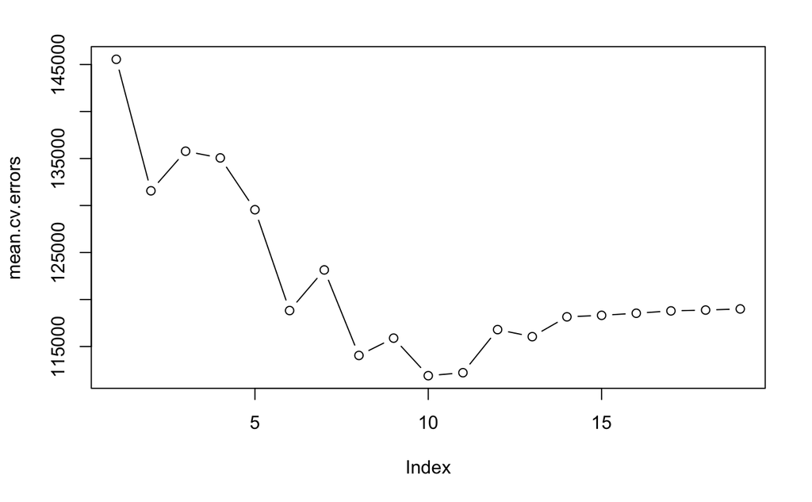

```r
par(mfrow = c(1, 1))

plot(mean.cv.errors, type = 'b')
```

```r
which.min(mean.cv.errors)
```

```
10
10
```

We see that cv selects a ten-variable model.

```r
reg.best = regsubsets(Salary ~ ., data = Hitters, nvmax = 19)

coef(reg.best, 10)
```

```
 (Intercept)        AtBat         Hits        Walks       CAtBat        CRuns         CRBI       CWalks
 162.5354420   -2.1686501    6.9180175    5.7732246   -0.1300798    1.4082490    0.7743122   -0.8308264
   DivisionW      PutOuts      Assists
-112.3800575    0.2973726    0.2831680
```